# Bagging, Random Forests, Boosting

Ryan Kelly

July 14, 2014

[Visit my website](http://rmdk.ca/) for more like this!

#### Data Sources:

Heavily borrowed from:

- Textbook: [Introduction to statistical learning](http://www-bcf.usc.edu/~gareth/ISL/)
- Textbook: [Elements of statistical learning](https://statistics.stanford.edu/~tibs/ElemStatLearn/)
- UCLA Example [link](http://www.ats.ucla.edu/stat/r/dae/logit.htm)
- [Wikipedia](http://en.wikipedia.org/)

```r
require(knitr)
```

## Overview

For an introduction to tree based methods, which this lecture builds upon. See my other notebook [here](http://rpubs.com/ryankelly/dtrees). The new methods explained here build upon these basics to construct more powerful prediction models, and remedy some of the drawbacks of classical tree methods.

## Bagging

It turns out that bootstrapping can be used in a different context that usual for improving tree based learning methods. Recall that decision trees suffer from *high variance*. This means that if we split the training data into two parts at random, and fit a decision tree to both halves, the results that we may get could be quite different. What we really want is a result that has low variance if applied repeatedly to distinct data sets. Bootstrapping of course is a natural solution, since it is designed as a general-purpose procedure for reducing variance. **Bagging** is essentially taking repeated samples from the single training set in order to generate *B* different bootstrapped training data sets. We then train our method on the *b*th training set and average all the predictions.

For decision trees, we simply construct *B* regression trees using *B* bootstrapped training sets, and average the resulting predictions. The trees are grown deep and are not pruned. Thus each individual tree has high variance, but low bias. Averaging these *B* trees reduces the variance. Bagging can dramatically reduce variance by combining hundreds or thousands of trees into a single procedure. For a qualitative *Y*, the simplest solution is for a given observation, we record the class predicted by each *B* tree and take a *majority vote*. Generally, the value of *B* is not critical. In practise we use a value of *B* sufficiently large that the error has settled down.

### Out-of-Bag Error Estimation

There is an easy way to estimate the test error of a bagged model, without the need for cross-validation. One can show that on average, each bagged tree makes use of around two-thirds of the observations. The remaining one-third of the observations not used to fit a given bagged tree are referred to as the out-of-bag (OOB) observations. We can simply predict the response for the *i*th observation using each of the trees in which that observation was OOB. This yields around *B* / 3 predictions for the *i*th observation. To obtain a single prediction for the *i*th observation we average those predicted responses, or take a majority vote, depending on if the response is quantitative or qualitative. Since an OOB prediction can be computed for all *n* observations, an overall OOB MSE or classification error rate can be computed. This is an acceptable test error rate because the predictions are based on only the trees that were not fit using that observation.

One problem with computing fully grown trees is that we cannot easily interpret the results. And it is no longer clear which variables are important to the relationship. However, we are able to obtain an overall summary of the importance of each predictor using the RSS or Gini index (for classification). We simply record the total amount that the RSS is decreased due to splits over a given predictor, averaged over all *B* trees. A large value then indicates an important predictor.

## Random Forests

Random forests provides an improvement over bagged trees by using a small tweak that *decorrelates* the trees. As in bagging, we build a number of trees based on bootstrapped training samples, but this time a split in a tree is considered, a random sampled of *m* predictors is chosen as split candidates from the full set of *p* predictors. The split is then allowed to only use one of those *m* predictors. A fresh sample of *m* predictors is taken at each split, where *m* is approx. equal to the square root of the total number of predictors. In other words, at each split in the tree, the algorithm is not even allowed to consider a majority of the available predictors. Let’s explain an example…

Suppose that there is one very strong predictor in the dataset, along with a number of other moderately strong predictors. In the collection of bagged trees, most of the trees will use this very strong predictor in the top split, consequently making most of the bagged trees look quite similar, and be highly correlated. Unfortunately, averaging many highly correlated quantities does not lead to as large of a reduction in variance as averaging many *uncorrelated* quantities. Random Forests overcomes this problem by forcing each split to consider only a subset of the predictors. Thus, on average, (*p* - *m*) / *p* of the splits will not even consider the strong predictor. This is what is meant by *decorrelating the trees*. If *m* = *p* then random forests is equal to bagging.

Using a small value of *m* will typically be helpful with a large number of correlated predictors.

## Boosting

Boosting is another approach for improving the prediction power from a decision tree. Boosting works similarly to *bagging* except that the trees are grown *sequentially* each tree is grown using information from previously grown trees. Boosting also does not involve bootstrapping, instead each tree is fit on a modified version of the original data.

Instead of fitting a single large decision tree, which results in hard fitting the data, and potentially overfitting. The boosting approach learns slowly. Given the current model, we fit a decision tree to the residuals from the model, rather than the outcome *Y*. We then add this new decision tree into the fitted function in order to update the residuals. Each of these trees can be rather small, determined by a tuning parameter *d*. By fitting small trees to the residuals, we slowly improve the fit in areas where it does not perform well. A second tuning parameter *lambda* slows the processes even further by allowing more and different shaped trees to attack the residuals.

Boosting has three tuning parameters overall.

1. The number of trees *B*. Except we must note that boosting can over fit if *B* is too large, although this overfitting tends to not be very severe. We use cross validation to select B.
2. Shrinkage parameter *lambda*, a small positive number. This controls the boosting learning rate. Typical values are 0.01 or 0.001, but it depends on the problem. Smaller *lambda* requires larger *B* to achieve good performance.
3. The number of *d* splits in each tree, which controls the complexity of the boosting. Often *d* = 1 works well, where each tree is a stump, consisting of a single split.

In general, boosting can improve upon random forests, and are easier to interpret because of the smaller tree structure.

## Code Examples

Here we will be using the `Boston` dataset and the `randomForest` package. We will not discuss bagging, since boosting and random forests tend to outperform it.

```r
library(randomForest)
library(MASS)
attach(Boston)

kable(head(Boston))
```

| crim | zn | indus | chas | nox | rm | age | dis | rad | tax | ptratio | black | lstat | medv |
| --- | --- | --- | --- | --- | --- | --- | --- | --- | --- | --- | --- | --- | --- |
| 0.0063 | 18 | 2.31 | 0 | 0.538 | 6.575 | 65.2 | 4.090 | 1 | 296 | 15.3 | 396.9 | 4.98 | 24.0 |
| 0.0273 | 0 | 7.07 | 0 | 0.469 | 6.421 | 78.9 | 4.967 | 2 | 242 | 17.8 | 396.9 | 9.14 | 21.6 |
| 0.0273 | 0 | 7.07 | 0 | 0.469 | 7.185 | 61.1 | 4.967 | 2 | 242 | 17.8 | 392.8 | 4.03 | 34.7 |
| 0.0324 | 0 | 2.18 | 0 | 0.458 | 6.998 | 45.8 | 6.062 | 3 | 222 | 18.7 | 394.6 | 2.94 | 33.4 |
| 0.0690 | 0 | 2.18 | 0 | 0.458 | 7.147 | 54.2 | 6.062 | 3 | 222 | 18.7 | 396.9 | 5.33 | 36.2 |
| 0.0298 | 0 | 2.18 | 0 | 0.458 | 6.430 | 58.7 | 6.062 | 3 | 222 | 18.7 | 394.1 | 5.21 | 28.7 |

### Random Forest

The `mtry` attribute indicates how many predictors should be considered for each split of the tree. By default random forests uses *p* / 3 for regression trees, and sqrt *p* for classification trees. Here we use `mtry = 6`.

```r
library(caret)
set.seed(123)
split <- createDataPartition(y=Boston$medv, p = 0.7, list=FALSE)
train <- Boston[split,]
test<- Boston[-split,]

rf <- randomForest(medv~., data=train, mtry=6, importance = TRUE)
yhat <- predict(rf, test)

mean((yhat - test$medv)^2)
```

```
## [1] 15.89
```

```r
kable(importance(rf))
```

```
##
##
## |        | %IncMSE| IncNodePurity|
## |:-------|-------:|-------------:|
## |crim    |  12.775|      1151.560|
## |zn      |   4.311|        96.201|
## |indus   |   9.105|      1397.116|
## |chas    |   3.912|       112.488|
## |nox     |  18.885|      1226.846|
## |rm      |  45.656|     11853.517|
## |age     |  11.491|       667.527|
## |dis     |  11.965|      1328.489|
## |rad     |   4.225|       142.087|
## |tax     |  10.169|       756.604|
## |ptratio |  14.786|      1629.476|
## |black   |   7.286|       438.287|
## |lstat   |  25.109|      7708.697|
```

Two measures of variable importance are measured. The %IncMSE is based on the mean decrease in accuracy in predictions on the out of bag samples, when the given variable was excluded from the model. IncNodePurity is a measure of the total decrease in node impurity that results from splits over that variable, averaged over all trees. We can plot the importance with `varImpPlot()`.

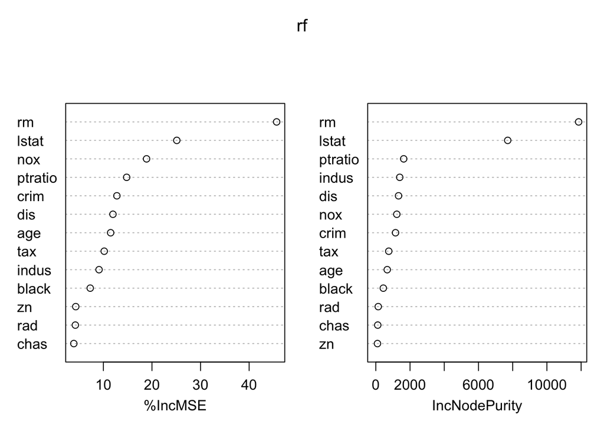

```r
varImpPlot(rf)
```

### Using the caret package

```r
# library(doMC)
# registerDoMC(6)

rf.caret <- train(medv ~., train,
            preProc=c('center', 'scale'),
            method='rf',
            importance=TRUE)

rf.caret
```

```
## Random Forest
##
## 356 samples
##  13 predictors
##
## Pre-processing: centered, scaled
## Resampling: Bootstrapped (25 reps)
##
## Summary of sample sizes: 356, 356, 356, 356, 356, 356, ...
##
## Resampling results across tuning parameters:
##
##   mtry  RMSE  Rsquared  RMSE SD  Rsquared SD
##   2     4     0.8       0.6      0.05
##   7     4     0.8       0.6      0.05
##   10    4     0.8       0.7      0.06
##
## RMSE was used to select the optimal model using  the smallest value.
## The final value used for the model was mtry = 7.
```

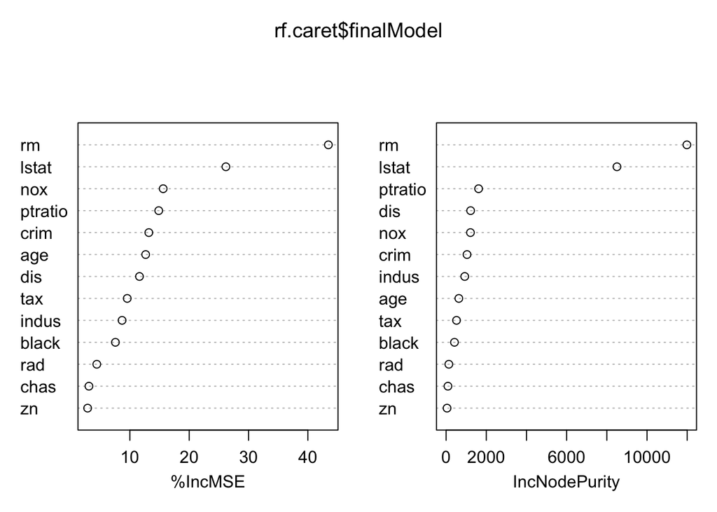

```r
varImpPlot(rf.caret$finalModel)
```

```r
yhat.caret <- predict(rf.caret, test)
mean((yhat.caret - test$medv)^2)
```

```
## [1] 16.04
```

## Boosting

For boosting we first use the `gmb` package and `gbm()` function to fit a boosted regression tree to the `Boston` data. The parameter `distribution = 'gaussian'` is used for regression, and `distribution='bernoulli'` is used for binary classification. The option `n.trees=5000` indicates that we want 5000 trees, and `interaction.depth` limits the depth of each tree.

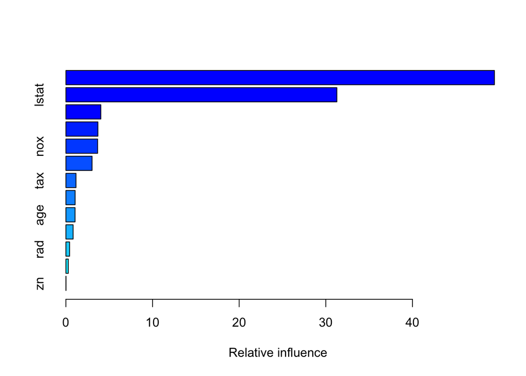

```
##             var  rel.inf
## rm           rm 49.46674
## lstat     lstat 31.27700
## ptratio ptratio  4.03148
## dis         dis  3.69630
## nox         nox  3.66330
## crim       crim  3.02230
## tax         tax  1.16808
## black     black  1.06541
## age         age  1.05657
## chas       chas  0.83213
## rad         rad  0.42701
## indus     indus  0.28017
## zn           zn  0.01349
```

```r
library(gbm)

boost <- gbm(medv~. , data=train,
             distribution = 'gaussian',
             n.trees = 5000,
             interaction.depth = 4)

summary(boost)
```

Clearly, `lstat` and `rm` are by far the most important variables. We can also produce `partial dependence plots` for these two variables, which illustrates the marginal effect of the selected variables on the response after integrating out the other variables. As we expect, median house prices increase with `rm` and decrease with `lstat`.

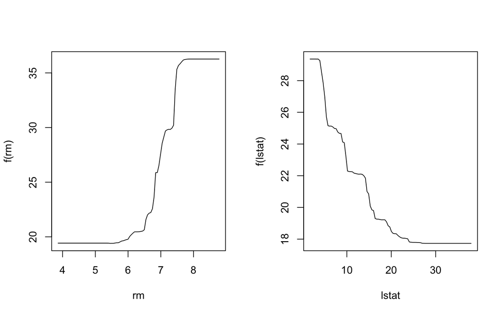

```r
par(mfrow=c(1,2))
plot(boost, i='rm')
plot(boost, i='lstat')
```

Now apply the boosted model to predict the test set.

```r
boost.pred <- predict (boost, test, n.trees=5000)
mean((boost.pred - test$medv)^2)
```

```
## [1] 17.12
```

Here we obtain a slightly higher MSE than random forests, however we have only used the default parameters. Let’s use `caret` to choose better parameters

```r
ctr <- trainControl(method = "cv", number = 10)

boost.caret <- train(medv~., train,
                     method='bstTree',
                     preProc=c('center','scale'),
                     trControl=ctr)
boost.caret
```

[output not shown]

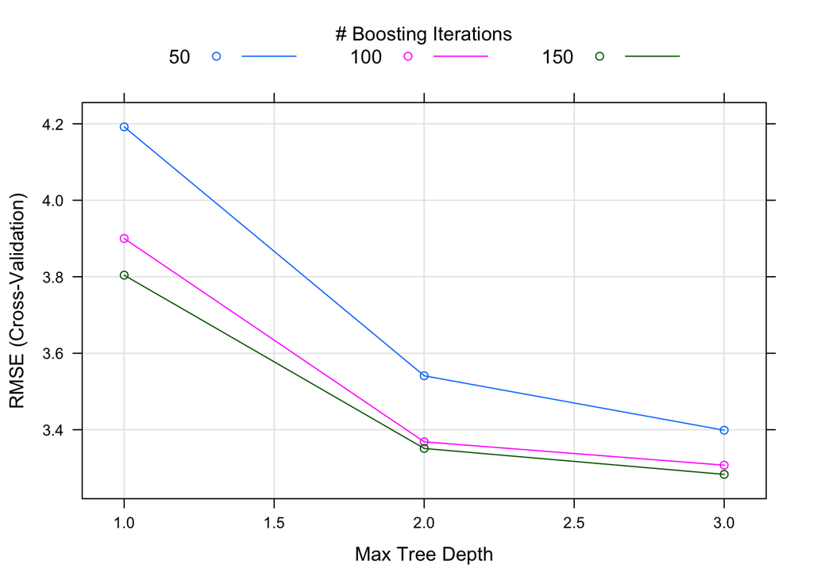

```r
plot(boost.caret)
```

```r
boost.caret.pred <- predict(boost.caret, test)
mean((boost.caret.pred - test$medv)^2)
```

```
## [1] 13.66
```

Here, with some better tuned parameters, we see a higher prediction accuracy than random forests.